# report

#### Alphabet（GOOG）[2025Q3]

### 一、财报简评

2025财年第三季度，Alphabet（谷歌母公司）交出了一份超预期的答卷：营收达到 **1023.5亿** 美元，同比增长约 **15.9%**，环比增长 **6.1%**，大幅超过市场普遍预期的 **999.0亿** 美元。净利润 **349.8亿** 美元，同比增长 **33%**；摊薄每股收益（EPS） **2.87美元**，远高于市场预估的 **2.29美元**。受益于搜索与YouTube广告的强劲表现、订阅业务的持续高增长以及云服务的爆发式扩张，本季经营杠杆明显改善，毛利率升至 **59.17%**，比去年同期提高1.33个百分点。

虽然欧洲委员会对谷歌处以 **35亿美元** 的反垄断罚款拉低了经营利润，但经营利润仍达 **312.3亿** 美元，经营利润率超过 **30%**。自由现金流 **245亿** 美元，得益于强劲的经营现金流和税收退款，高于上一季度的 **53亿** 美元。公司同时上调了全年资本开支预期，反映出对AI基建需求的信心。财报发布后，市场快速反应，Alphabet A 类股在盘后交易中上涨超 **5%**。

### 二、公司信息

Alphabet 是全球领先的科技巨头，旗下包含 Google 服务（搜索、YouTube、Google Play、Android 等）、Google Cloud 以及 Other Bets 等多元业务板块。公司以“AI first”为战略核心，通过大规模数据、算法和算力优势形成深厚护城河。目前主要业务包括：

- **搜索与广告业务：** 拥有全球最大搜索引擎和广告变现平台，涵盖 Google Search、AdWords、AdSense 等，贡献总收入的 **55%** 左右。
- **YouTube与订阅业务：** 包括 YouTube 广告、YouTube TV、YouTube Music/ Premium、Google Play 以及硬件设备，YouTube广告占比约 **10%**，订阅/平台/设备贡献约 **13%**。
- **云服务（Google Cloud）：** 提供 IaaS、PaaS、SaaS 及数据/AI 解决方案，2025Q3贡献营收 **151.6亿** 美元，同比增长 **34%**，收入占比升至约 **15%**。
- **Other Bets：** 包含自动驾驶公司 Waymo、健康科技公司 Verily 等，收入规模小，长期聚焦前沿创新。

公司定位可以概括为 **“双飞翼”模型：广告是现金牛，云与AI是增长曲线**。核心商业逻辑是在成熟的广告生态上，不断将搜索与YouTube流量变现，同时利用技术优势在云计算和生成式AI领域开辟新收入来源。随着 Gemini 等大模型在搜索、广告、工作套件中的广泛应用，AI 已成为公司下一阶段增长的重要驱动力。

### 三、关键数据：实际 vs 预期

| 指标 | 实际值 | 市场预期 | YoY | QoQ | 结果 |
| --- | --- | --- | --- | --- | --- |
| **营收（Revenue）** | **1023.5亿美元** | **999.0亿美元** | **+15.9%** | **+6.1%** | **超预期** |
| **EPS（每股收益）** | **2.87美元** | **2.29美元** | **+35.4%** | **+24.2%** | **超预期** |
| **毛利率（Gross Margin）** | **59.17%** | / | **+1.33pt** | **+0.23pt** | / |
| **净利润** | **349.8亿美元** | / | **+33.0%** | **+24.1%** | / |
| **经营现金流** | **485亿美元** | / | **+58%** | **+75%** | / |

整体数据显示，公司在营收和盈利层面均显著超越市场预期，尤其是 EPS 的超预期主要得益于高毛利广告收入增长和费用控制；经营现金流大幅增长则体现出业务现金创造能力强劲。

### 四、指引 vs 市场预期

Alphabet 传统上不提供具体季度营收或盈利指引。本次电话会中，管理层重点讨论了资本开支和云业务前景：

- **资本开支指引：** CFO 露丝·波拉特表示，2025年资本开支预计 **910–930亿** 美元，高于此前 **850亿** 美元的预期，其中约60%用于服务器（包括AI加速器），40%用于数据中心建设。管理层认为2026年资本开支可能进一步增加，用于满足生成式AI的算力需求。市场普遍预期85–90亿水平，因此调高指引被解读为 **upbeat**。
- **利润率指引：** 公司强调将继续控制运营费用，通过提高自动化和效率抵消员工和服务器成本增长。虽然短期因一次性罚款压低经营利润率，但中长期目标是维持30%左右的经营利润率区间。
- **全年更新与市场焦点：** 管理层未更新全年收入或利润目标，但指出广告需求保持稳健，YouTube和订阅业务增速有望维持两位数。市场关注点集中在 **AI 订单增速与云服务毛利率改善**，以及高额资本开支对自由现金流的影响。

### 五、增长与利润率

**收入增速与驱动因素：** 本季度 Google 服务收入增速达 **12%**，其中搜索与其他广告收入增长 **15%**，得益于搜索生成式体验和高意图广告产品的引入。YouTube 广告收入同比增长 **15%**，短视频 Shorts 的每日观看次数同比增长约 **25%**，CTV（联网电视）业务贡献显著。网络广告收入则受合作伙伴流量下降影响，同比下降 **3%**。订阅、平台与设备收入增长 **21%**，YouTube Premium 用户突破 1亿，硬件和Play生态也有贡献。云服务收入大增 **34%**，Generative AI Solutions、GCP 基础设施和 Gemini 模型的商业化带动企业客户支出，未公告的云订单储备（Backlog）同比增长 **46%** 至 **1550亿** 美元。

**现金流与资本配置：** 本季度自由现金流 **245亿** 美元，其中经营现金流 **485亿** 美元，资本开支 **240亿** 美元。由于税收退还及应收账款回款，经营现金流大幅增加。公司手握现金和有价证券 **985亿** 美元，并在本季度回购了 **158亿** 美元的股票。管理层强调高额资本开支将持续，但仍有足够的自由现金流支持回购和投资。

### 六、电话会要点 / 管理层重点

1. **AI 战略与产品进展**：CEO 桑达尔·皮查伊强调生成式 AI 在所有业务线的快速渗透。Gemini 模型已集成于搜索、广告、Workspace 和 YouTube，AI Overviews、AI Mode 等新功能表现良好。Gemini 应用月活跃用户超过 **6.5亿**。公司计划在今年底推出更大规模的模型版本，强化多模态和推理能力。
2. **云业务与订单储备**：GCP 收入增长 **34%**，并实现 **30.5%** 的经营利润率，凸显规模效应。云订单储备同比增长 **46%**，达 **1550亿** 美元，涵盖 AI 基础设施和应用平台。CFO 指出已有大量生成式AI项目在测试和部署阶段，对未来营收贡献可期。
3. **资本开支与供应链**：公司将全年资本开支指引上调至 **910–930亿** 美元，主要用于 AI 加速器和数据中心。管理层坦言供应链环境仍然紧张，但通过长期采购协议锁定产能，计划在未来几年持续高投入。云数据中心的建设周期较长，预计2026年资本开支仍维持高位。
4. **广告与订阅业务**：搜索广告和 YouTube 广告保持双位数增长。Performance Max、Shopping Ads 等产品帮助广告主提高转化率。YouTube Shorts 的货币化能力改善，广告点击和单价均同比提升。订阅业务（YouTube Premium、YouTube TV、Google One）收入增长 **21%**，用户留存率高。
5. **成本控制与回购**：管理层强调在投资 AI 的同时，会严格控制运营开支，通过流程自动化减少人力成本，对低优先级项目进行调整。本季度公司回购 **158亿** 美元股票，未来将继续利用自由现金流进行回购和投资。
6. **管理层语气**：整体语气乐观，强调AI带来的长期机会，但也提醒宏观环境和广告市场存在波动。CFO 提及货币汇率和利率变动可能带来季度波动，建议投资者关注长期趋势而非单季波动。

### 七、持续关注的老问题

- **盈利质量 / 股权激励压力：** 虽然利润率提升，但员工股权激励（SBC）仍然较高；管理层称将控制人力增速，通过自动化降低SBC占比，短期未见明显改善。
- **宏观广告或周期风险：** 全球宏观经济仍存不确定性，广告主预算可能随周期缩减；管理层指出目前需求稳健，但保持谨慎以应对潜在放缓。
- **监管与法律风险：** 欧盟和美国的反垄断诉讼持续推进，本季度已经确认 **35亿美元** 罚款。未来若发生更多判决，可能影响利润和业务模式。
- **云服务竞争与定价压力：** AWS 和微软等竞争对手在AI领域投入巨大，云市场竞争激烈。虽然Alphabet云利润率改善，但仍需关注价格战和客户议价对毛利的影响。
- **高额资本开支 / 现金流压力：** AI 基建投入导致资本开支大幅抬升。短期内自由现金流可能波动；长期投资回收周期较长，需要密切跟踪回报率。
- **Other Bets 的盈利能力：** 自动驾驶（Waymo）等长期项目仍处于商业化早期，亏损持续，何时盈利尚不确定。

### 八、风险与机会

**机会（多头逻辑）：** 1. **AI 应用成熟 → 广告 ROI 提升 → 预算扩张：** 如果生成式 AI 继续提升广告匹配效率，广告客户的投资回报率提高，将促使客户增加预算，推动搜索和 YouTube 收入加速增长。 2. **云服务订单转化 → 收入提速：** 随着云订单储备不断转换为实际消费，尤其是 AI 基础设施和 Gemini 服务的落地，云业务收入增速有望维持高位，毛利率进一步提升。 3. **订阅与硬件生态扩大 → 收入结构多元化：** YouTube Premium、Google One 和 Pixel 设备等订阅及硬件生态规模扩大，可减少对广告收入的依赖，提高收入稳定性。 4. **高自由现金流 → 回购与分红 → 每股盈利增厚：** 现金储备充裕并持续回购股票，有望提升每股收益并对股价形成支撑。 5. **成本控制与效率提升 → 运营杠杆释放：** 若自动化和效率提升进一步压缩费用率，经营利润率有望在高收入增长背景下持续提升，估值或迎来向上重新定价。

**风险（空头逻辑）：** 1. **宏观经济放缓 → 广告预算缩减：** 若全球经济走弱，企业营销预算减少，将直接压制搜索和YouTube广告收入增长，盈利敏感度高。 2. **AI 竞争加剧 → 研发成本上升：** OpenAI、微软及其他新兴模型供应商快速迭代，迫使谷歌持续投入巨资升级模型，研发费用可能超预期并挤压利润率。 3. **监管诉讼与巨额罚款 → 商业模式受限：** 反垄断诉讼可能导致结构性整改或巨额罚款，影响搜索、广告定价和平台策略。 4. **云服务竞争激烈 → 定价压力加大：** AWS、Azure 在企业AI服务领域具有先发优势，若价格战升级或客户议价增强，谷歌云毛利率可能承压。 5. **高资本开支 → 现金流波动：** AI 数据中心与自研芯片投资巨大，如回报周期拉长，可能引发投资者对自由现金流的担忧。

> **口语总结：** AI浪潮下，谷歌“广告吃饭、云练兵”，机会在于将算力和模型变现，风险在于周期与监管博弈。

### 九、特别说明 / 投资启示

本季财报展现了 Alphabet 在广告和云两大核心业务线上的强大韧性与增长潜力。AI 技术已深入搜索、广告、办公套件及云平台，驱动营收和利润率持续提升。伴随Gemini 等模型的迭代，公司提前锁定 AI 基建资源，通过加大资本开支巩固长期竞争力。虽然一次性罚款和巨额投入导致短期利润率波动，但公司强劲的自由现金流和庞大的现金储备足以支持回购和持续投资。  
对于投资者而言，需区分短期情绪和长期价值：短期看，广告需求和宏观环境仍可能波动，CapEx快速上行或引发估值修正；长期看，AI能力和云订单储备奠定了持续增长的基础。

> **人话结论：** 基本面在修复，AI 发力让未来更具想象力，短期波动不改长期向上逻辑。

### 十、可视化扩展

#### （1）数据来源与口径

数据主要来自 Alphabet 公司投资者关系网站发布的财报及电话会议资料，并辅以 MacroTrends 公布的季度历史数据。数据区间覆盖 **2022Q1–2025Q3**，以季度为粒度；货币统一采用 **亿美元**（1亿美元=0.1B），缺失的经营现金流、资本开支数据以空白表示。毛利率为最近十二个月（TTM）口径，部分指标因公司未披露而标注“/”。

#### （2）主要经营指标数据

[output not shown]

单位为 **亿美元**；斜杠“–”表示公司未披露数据。经营现金流、CapEx 和自由现金流数据取自财报中的现金流量表或电话会披露。

#### （3）主营业务或产品数据

| 业务/产品 | 收入占比 | YoY | 备注 |
| --- | --- | --- | --- |
| 搜索及其他广告 | ≈55% | +15% | 核心现金牛，受益于生成式搜索体验、Performance Max 等广告工具推动。 |
| YouTube广告 | ≈10% | +15% | Shorts 观看增长、CTV 渗透提升广告单价；直播收入创历史新高。 |
| 网络广告 | ≈7% | –3% | 受合作伙伴流量下滑和宏观环境影响呈负增长。 |
| 订阅/平台/设备 | ≈13% | +21% | YouTube Premium/TV 增长强劲，Pixel 和 Play 生态贡献稳定。 |
| 云服务（GCP & Workspace） | ≈15% | +34% | AI 基础设施需求旺盛，企业客户积极采用 Gemini 与生成式AI解决方案。 |
| 其他业务 (Other Bets) | <1% | / | Waymo、Verily 等早期项目，收入规模小，亏损持续。 |

#### （4）趋势可视化（图表清单）

1. **营收与经营利润趋势（双轴折线）**

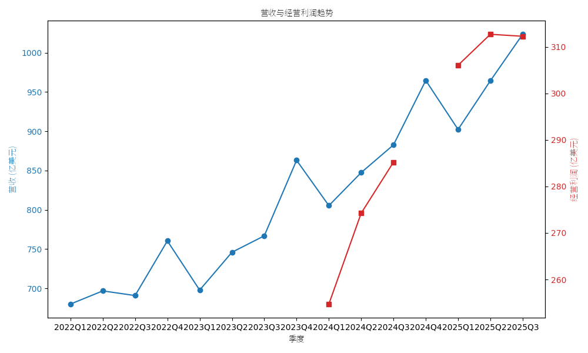

   *图注：营收（左轴）和经营利润（右轴）均呈稳步上升趋势，2025Q3经营利润因一次性罚款略有波动。*
2. **利润率变化：毛利率/经营利润率/净利率**

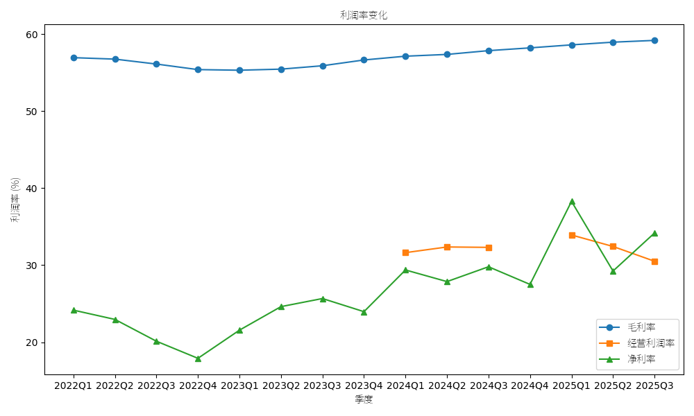

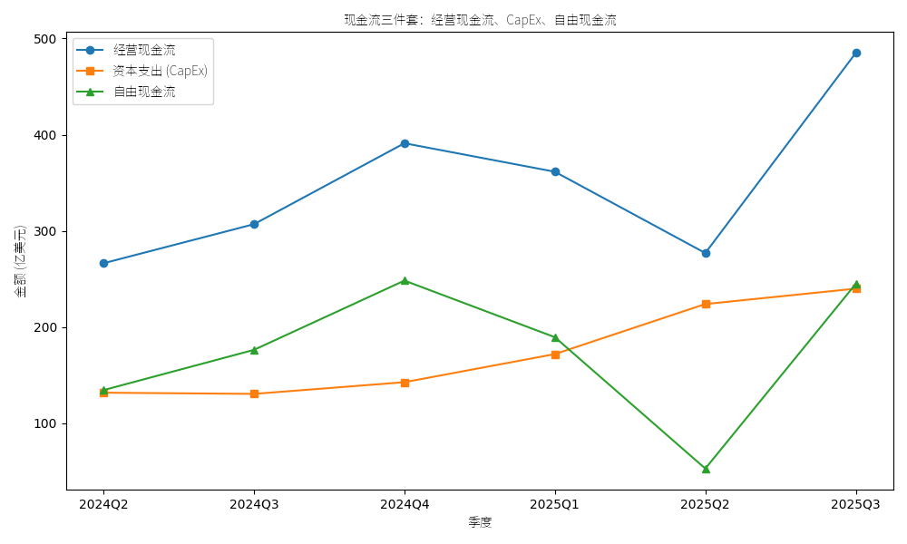

   *图注：经营现金流在税收退还及应收账款回款支持下大幅提升；高额资本开支导致自由现金流波动，但整体保持正值。*
4. **产品结构与收入占比**

[figure not shown]

   *图注：广告业务仍占绝对主导地位，云服务收入占比快速提升，订阅/硬件等业务成为重要补充。*
5. **实际 vs 一致预期（营收与EPS）**

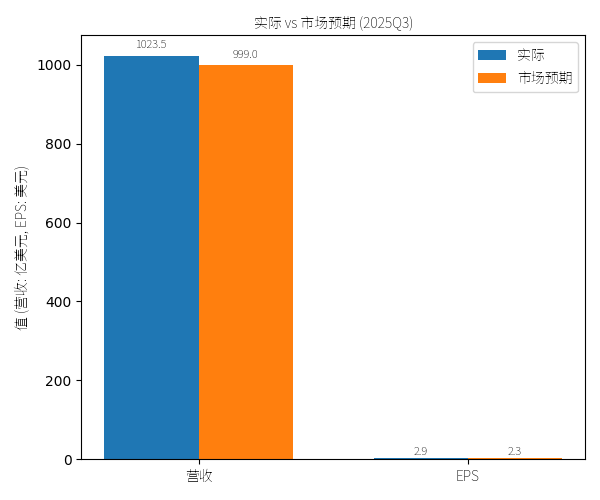

   *图注：2025Q3的营收和EPS均大幅超过一致预期，凸显公司经营优势。*

#### （5）数据来源与时间戳说明

本文数据来源于 Alphabet 公司 2025Q3 财报及电话会议、前数季度财报、MacroTrends 公开数据库等。时间范围截至 **2025年11月9日**（美国洛杉矶时间），如未来公司发布修订或更新数据，请以最新披露为准。